# Cross Validation

Day 15

## Cross-Validation

- Previously, we discussed the issue of over-fitting
  - model is fitted using **training data set**
  - model is applied to a different **test data set**
  - If the model is over-fit to the **training data**, it might not explain the **testing** data well
- Today we will discuss methods that can help prevent over-fitting
  1. Simple split of training/testing set
  2. k-fold cross-validation (CV)
  3. leave one out cross validation (LOOCV)

## Cross-validation error measure

- When we discussed continuous variables, we used the `MSE` as our metric for a good model
- If \(Y\) is binary, the analogus metric is the **error** for a model (1-accuracy) \[ Error = \dfrac{\sum_{\textrm{data}} I(y \neq \hat{y})}{n} = \dfrac{FN + FP}{n}= 1- Accuracy \]

## Goal of Cross-validation

- Make sure the `test error` is not too high so that we aren’t over-fitting
- If we have a good `test dataset` we can simply use that to evaluate the error
- In most cases, we don’t have a good `test dataset`
  - For stock market data, we want to make sure the model works well on **future** data
  - When predicting a recession, we also want to make sure the model works well on **future** data
- If we don’t have a good `test dataset` what is the next best alternative?
  - Keep some portion of the `training dataset` aside for use as a `test dataset`

## Simulated example

- Suppose we have the following model describing the “true” relationship between `y` and `x`: \[ \pi(x) = \dfrac{e^{-1 - x + x^2}}{1 + e^{-1 - x + x^2}} \]
- Here is the probability curve along with \(n=200\) simulated responses given a set of \(x\)’s

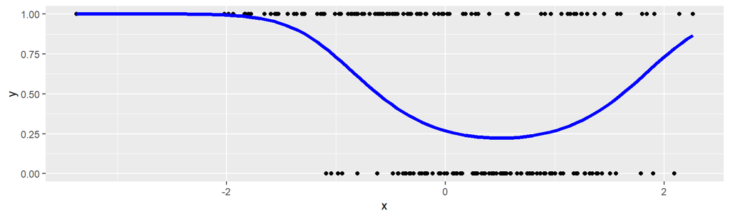

## Simulated example

- Pretend we don’t know the “true” relationship and we want to decide what order polynomial to use to fit the model

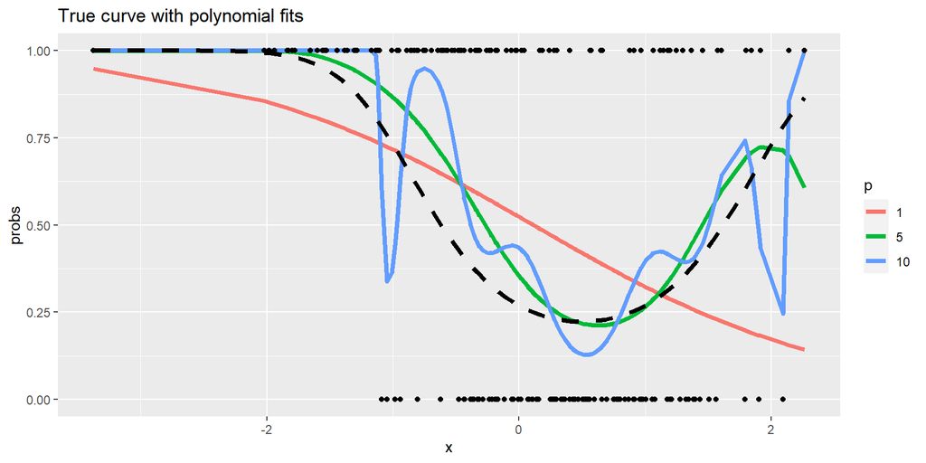

## Simulated example

- Ideally, we would plot the `training error` vs `testing error`

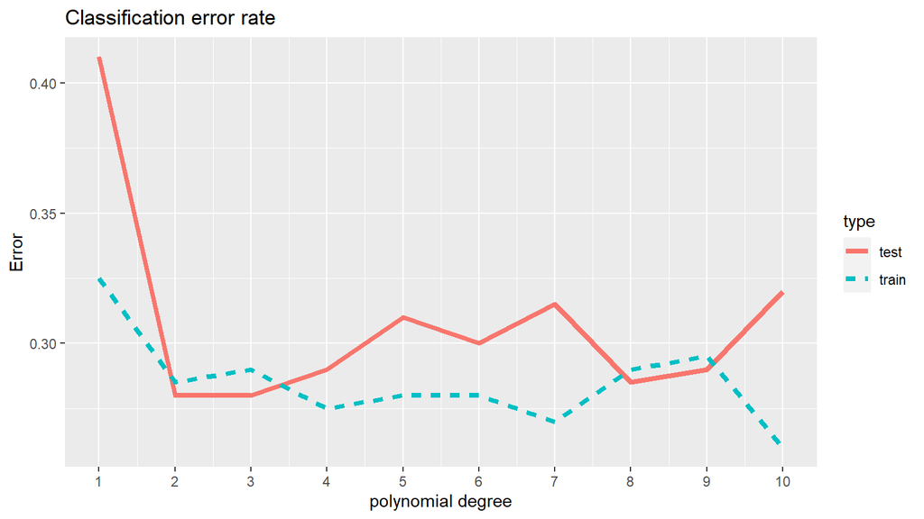

- Which polynomial would you choose?

## Simple sample split

- What if we don’t have a `testing dataset`?
- One idea is to split the data 50/50 into training and testing

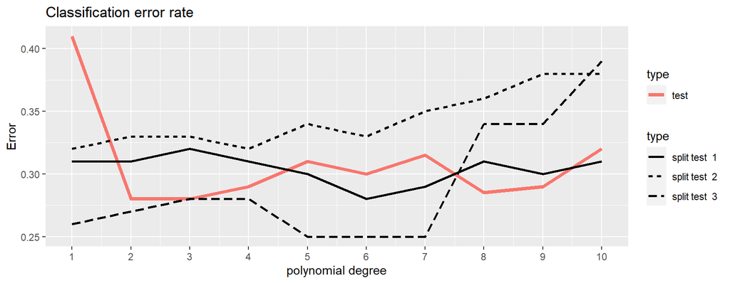

- What are the downsides?
  - Lots of variation due to random sampling
  - Smaller sample size because we use less of the data

## k-fold cross validation

- create \(k-\)folds (non-overlapping subsets) of the data of similar sizes
- training data: \(k-1\) folds
- test data: the one left-out fold
- error for fold \(i\): \(err_i\) is the error rate for this test set
- For each of the \(k\) folds we compute \(err_i\).
- k-fold CV error: \[ cv_{(k)} = \dfrac{1}{k}\sum_i err_i \]
- Ameliorates both of the issues with simple sample split because we average over multiple instances

## k-fold cross validation

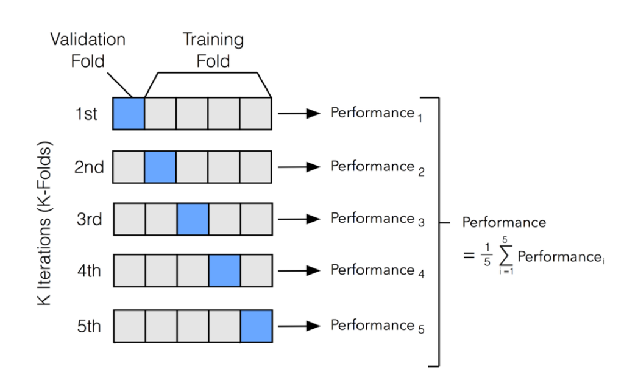

## Leave one out cross validation (LOOCV)

- training data: \(n\) training sets of \(n-1\) cases
- test data: \(n\) test sets of 1 case
- error for test set \(i\): \(err_i = I(y_i \neq \hat{y}_i)\)
- LOOCV error: average over all \(n\) test sets \[ cv_{(n)} = \dfrac{1}{n}\sum_i err_i \]
- In the limit as \(k \rightarrow n\), CV becomes LOOCV

## Computing CV errors

- A number of packages can do cross validation for a variety of model types
- The package `boot` contains a function `cv.glm(data,glm,cost,K)` that computes cross-validation error estimates for a given glm
  - error given by `delta[1]` output from this function
- For logistic regression, we just need to define the error `cost` function:

```
cost <- function(y, pi) 1-mean(y==(pi>t))
```

- `y` are binary (0/1) responses
- `pi` are fitted (estimated) probabilities
- `t` is our threshold

## LOOCV errors

- LOOCV procedure pretty similar to true `test` error. Of course in reality, we can’t compute true `test` error

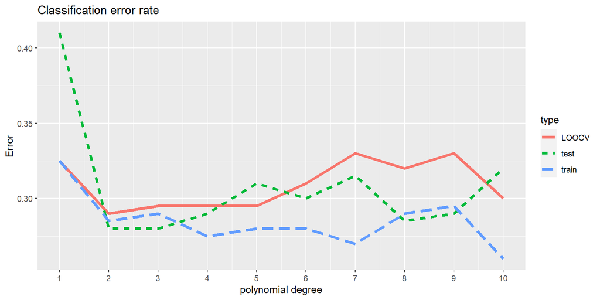

## CV errors

- \(k=5,10\) pretty similar to LOOCV but faster

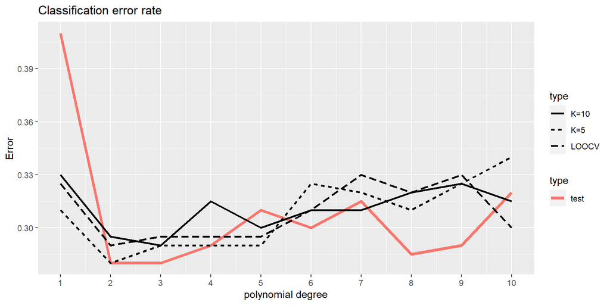

## LOOCV vs. k-fold CV

- k-fold:
  - less computational power/time than LOOCV
  - “intermediate” level of bias, but less bias than assessing error without cross-validation
  - Remember to `set.seed(n)` before your command or else you will get a different answer each time. Why?
- LOOCV:
  - approximately unbiased estimates of the true error
  - Don’t need to `set seed`. Why?
- The authors of `ISLR` claim that empirical evidence suggest using k-fold cv with \(k=5\) or \(k=10\).

## Things to keep in mind about LOOCV and k-fold CV

- When we use these methods, what assumptions are we making about the training vs. testing sets?
- Implicitly, we are assuming that the training data is similar to the testing data that we care about
- This assumption might not always hold
  - Using 2016 election data to predict 2020. It could be that the population has changed, or something changed that isn’t captured in our observable values
  - Using the relationship between hours of study and test scores in this class may not be a good representation of future classes